# Is bad stronger than good? A reanalysis of the valence asymmetry in Paolini et al. (2024)

Author

Lukas Wallrich

Published

July 27, 2026

## Summary

Paolini et al. (2024) synthesise seventy years of intergroup contact research and report that the association between negative contact and prejudice is significantly stronger than the association between positive contact and prejudice, a “bad is stronger than good” asymmetry that they interpret through sequential sampling and self-selection. Using their public workbook, I reproduce their asymmetry test exactly, and then show that it does not survive two checks that share no modelling choice. The first concerns the random-effects structure, which fixes rather than estimates the correlation between a sample’s positive- and negative-contact effects. The second leaves the model untouched and asks how firmly the estimate is pinned down once the workbook’s own design and quality codes are taken into account.

The published test contrasts coefficients from a model fitted to *signed* correlations, in which positive-contact effects are negative and negative-contact effects positive, with a random intercept shared across contact valence. For samples contributing both valences, that shared intercept implies that the two effects, expressed in the direction each valence predicts, deviate from their means in exactly opposite ways: the correlation between a sample’s two latent deviations is fixed at $-1$. When I estimate that correlation instead of fixing it, it is strongly positive at both levels of the hierarchy, 0.69 across samples (profile-likelihood CI [0.41, 0.85]) and 0.88 across papers, and the model fits far better. Under that specification the asymmetry is -0.042 (95% CI [-0.084, 0.001], *p* = .057), which is itself not distinguishable from zero, rather than the published 0.090 (*p* = .009).

The published estimate is also loosely pinned down within its own design. Keeping the model, the estimator and the coding, and refitting on the clearly-valenced effects inside subsets defined by the authors’ own quality codes, moves the contrast between -0.054 and 0.140; among the effects the coders rated the purest tests of the contact–outcome link it is 0.040 (*p* = .348). Adjusting the full sample for the workbook’s design and context codes leaves 0.075, 95% CI [-0.020, 0.171]. Tested as interactions rather than subsets, though, the quality codes do not show a consistent gradient, and one of them favours the published claim.

The design that isolates valence most directly points against it. Among the samples that measured both positive and negative contact against the *same* coded outcome (191 matched pairs from 67 samples in 41 papers, *N* ≈ 22,667), the negative-contact association was slightly *smaller*, not larger: -0.053 (95% CI [-0.093, -0.013], *p* = .012).

Those samples are not typical of the workbook. Their positive-contact associations are stronger than elsewhere (*r* = 0.343 against 0.257), by more than the asymmetry under dispute, and the workbook’s design and quality codes explain only part of that gap. The within-sample estimate is therefore clean about what valence does inside a study and silent about the literature’s average.

Taken together I do not think this workbook establishes a general negativity asymmetry in contact–prejudice associations. This bears specifically on the meta-analytic claim that the two coded associations differ in size. It leaves the paper’s substantive contribution on contact valence and self-selection intact, and it does not show that negative contact experiences matter less psychologically.

## Why the distinction matters

Positive and negative contact are not sampled from the world in the same way. How often people encounter each, and whether researchers choose to measure each, both depend on context: studies in settings of open conflict are more likely to measure negative contact, and studies of everyday diversity more likely to measure positive contact. Sample composition, outgroup, measures and analytic conventions therefore travel with contact valence. Comparing a pool of positive-contact effects to a largely different pool of negative-contact effects puts all of that in the comparison alongside valence itself.

The workbook shows this directly. Of the 205 samples contributing usable positive- or negative-contact effects, 119 measured positive contact only and 8 negative contact only; 78 measured both. The imbalance is one-sided: almost every sample contributing a negative-contact effect also contributes a positive-contact one, while 119 of the 197 samples contributing positive-contact effects have no negative-contact counterpart. The published contrast therefore compares a negative-contact pool drawn almost entirely from studies that measured both valences against a positive-contact pool that is mostly drawn from studies that did not. As I show below, that imbalance is what allows a cross-valence constraint to move the estimate so far, and it is also where the difference between the published result and mine turns out to sit.

## The published test reproduces exactly

Table 1: Contact valence effects from the published multilevel model, refitted from the authors’ public workbook.

Reproduction of the published valence estimates

| Valence | Fisher z | 95% CI | r |
| --- | --- | --- | --- |
| Positive | −0.298 | [-0.332, -0.264] | −0.289 |
| Ambivalent | −0.135 | [-0.180, -0.090] | −0.135 |
| Negative | 0.388 | [0.353, 0.423] | 0.370 |
| Unclassifiable | −0.236 | [-0.281, -0.192] | −0.232 |

Fitting the authors’ model, a three-level random-effects meta-analysis of Fisher-transformed correlations with effects nested in samples, studies and papers, returns their published estimates to four decimal places. Their test of the asymmetry, labelled the “evaluative congruence test” in their Appendix K1, adds the positive and negative coefficients, which is a difference of magnitudes because the two have opposite signs: 0.090 (*SE* = 0.035, *z* = 2.60, *p* = .009). I reproduce that value exactly, so what follows concerns the specification rather than the data handling.

I keep the authors’ Fisher-*z* scale throughout, including for the within-sample differences below. On the raw correlation scale the sampling variance of an estimate depends on its own magnitude, so a difference between two correlations is weighted by how large they happen to be, which is precisely the quantity under test. After the transformation the sampling variance is $1/(n-3)$ whichever valence the effect belongs to, so the two sides of the contrast enter on equal terms. Because the correlations here are small, the two scales stay close: the within-sample contrast reported below is -0.053 on the *z* scale, against a difference in mean correlations of -0.050 (*r* = 0.300 for negative contact versus 0.349 for positive).

## What the shared random intercept assumes

Because the asymmetry hypothesis is about which association is *stronger*, both valences have to be placed on a common scale before they can be compared. I call this congruent coding: the sign of positive-contact effects is flipped, so that a larger value means “more strongly associated with prejudice in the direction this valence predicts”. This is not an absolute value, since the 39 effects that run against their valence’s predicted direction keep a negative value.

Write the signed effect for effect $i$ in sample $s$ as $y_{is} = \beta_v + u_s + \varepsilon_{is}$, the published structure. A sample’s two effects are $\beta_{pos} + u_s$ and $\beta_{neg} + u_s$, with $\beta_{pos} < 0 < \beta_{neg}$. Read in congruent coding, they are $-\beta_{pos} - u_s$ and $\beta_{neg} + u_s$: the sample-level deviations are $-u_s$ and $+u_s$, so their correlation is fixed at exactly $-1$. The model therefore takes for granted that a sample in which positive contact is unusually strongly associated with lower prejudice is one in which negative contact is unusually *weakly* associated with higher prejudice.

Adding the two fitted coefficients afterwards, “as if the Pos coefficient had been made positive” in the authors’ words, does not remove this. The coefficients are generalised least squares estimates, so the assumed covariance structure determines the weights that produced them; changing the sign of a coefficient after the fact does not change the weights.

The constraint is consequential here because the design is so unbalanced. Had every sample measured both valences, a shared intercept would simply cancel from the within-sample difference. With 119 positive-only and 8 negative-only samples against 78 that measured both, the variance components are identified largely by single-valence samples, and an implausible cross-valence correlation propagates into the weights that set the fixed effects.

## Estimating the correlation instead of fixing it

Under the same random structure, congruent coding merely replaces the $-1$ with $+1$, which is why that model reports an implausibly narrow interval. The informative comparison lets the random effects differ by valence, so the correlation becomes a parameter. Such a specification also has the property one would want of a test about magnitudes: it gives identical results under either sign convention.

Table 2: The valence contrast under each covariance structure. So that AIC is comparable, every model here uses the same two grouping levels, paper and sample; the shared-intercept rows are therefore the published covariance structure refitted without the study level, which changes its contrast by less than .002. The two codings differ by a sign flip, a transformation with unit Jacobian, so their likelihoods are on the same scale.

Sensitivity of the asymmetry to the assumed cross-valence correlation

| Covariance structure | Coding | Cross-valence r | Asymmetry (z) | SE | p | AIC |
| --- | --- | --- | --- | --- | --- | --- |
| Random intercept shared across valence (published) | signed | -1 | 0.109 | 0.036 | 0.002 | 6,709 |
| Random intercept shared across valence (published) | congruent | +1 | −0.048 | 0.005 | 0.000 | 5,145 |
| Valence-specific, correlation fixed at zero | signed | 0 | 0.032 | 0.038 | 0.394 | 4,595 |
| Valence-specific, correlation fixed at zero | congruent | 0 | 0.032 | 0.038 | 0.394 | 4,595 |
| Valence-specific, correlation estimated | signed | estimated | −0.041 | 0.021 | 0.049 | 4,550 |
| Valence-specific, correlation estimated | congruent | estimated | −0.041 | 0.021 | 0.049 | 4,550 |

Three things follow. The published structure and its congruent-coded twin disagree in sign, so at most one of them describes the data. Both fit markedly worse than the specification that estimates the correlation, by 2159 and 595 AIC units. And the estimated correlations are positive at both levels: sample-level 0.69, profile-likelihood interval [0.41, 0.85], and paper-level 0.88, [0.72, 0.97]. Both intervals exclude not only $-1$ but every negative value. The sample-level estimate is the one the algebra above concerns.

That direction is what the usual sources of sample-level variation in effect size would predict. Measurement reliability, restriction of range on the outcome, shared method variance and how prejudice is operationalised should raise or lower both associations together, which is a positive correlation between the two magnitudes.[^1]

Under the lowest-AIC specification of those compared, the asymmetry is -0.042 (95% CI [-0.084, 0.001], *t*(47.3) = -1.95, *p* = .057), with estimated associations of *r* = 0.276 for positive and *r* = 0.237 for negative contact. Standard errors use cluster-robust variance estimation with the CR2 correction and Satterthwaite degrees of freedom, clustering on paper (Pustejovsky and Tipton 2022). The same is true of every contrast reported below, including the covariate-adjusted ones.

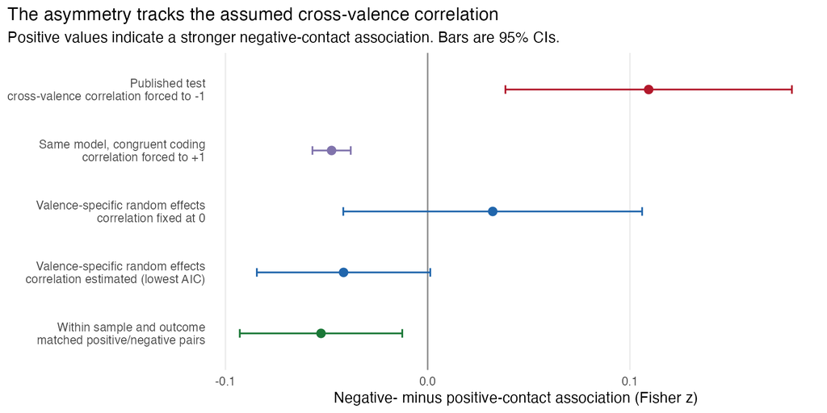

Figure 1: The valence contrast under each covariance structure and under the matched within-sample design.

## The published estimate across the workbook’s own quality codes

The specification argument can be set aside entirely and the published number still moves. Table 3 refits the published covariance structure, on the published coding, with the published estimator and the published three-level hierarchy, inside subsets of the same between-study design defined by the workbook’s own quality codes. Nothing about the model changes; only which effects are included. The zero-correlation column alongside it has to drop the study level, because metafor allows at most two valence-specific random terms.

The baseline in that table is 0.109 rather than the published 0.090. The difference is the analysis sample, not the model: restricting to the clearly positive and clearly negative effects, and dropping the ambivalent and unclassifiable categories that the contrast does not concern, raises the published estimate from 0.090 to 0.109. Both are fitted with the same three-level hierarchy and estimator. Restricting to the effects the contrast is actually about therefore raises the published asymmetry rather than lowering it.

Table 3: The published contrast, and the neutral zero-correlation baseline, refitted inside subsets defined by the workbook’s own quality codes. Positive values indicate a stronger negative-contact association.

The published contrast inside more comparable subsets

| Subset | Pos/Neg effects | Samples | Published structure | p | Correlation fixed at zero | p |
| --- | --- | --- | --- | --- | --- | --- |
| All positive/negative effects | 612 / 263 | 205 | 0.109 | 0.003 | 0.032 | 0.400 |
| Purest contact–outcome pairings | 324 / 171 | 124 | 0.040 | 0.348 | 0.019 | 0.625 |
| Better contact measure | 249 / 97 | 103 | 0.140 | 0.009 | 0.056 | 0.258 |
| Better outcome measure | 159 / 68 | 86 | 0.047 | 0.407 | −0.023 | 0.720 |
| Published 2010 or later | 490 / 224 | 155 | 0.073 | 0.048 | 0.038 | 0.229 |
| Purest and 2010 or later | 277 / 146 | 103 | 0.034 | 0.492 | 0.018 | 0.643 |
| Purest on the outcome side only | 370 / 182 | 140 | 0.052 | 0.238 | 0.024 | 0.571 |
| Purest and both measures better | 71 / 43 | 48 | −0.054 | 0.347 | −0.048 | 0.528 |

The contrast ranges from -0.054 to 0.140 across these subsets, and only 3 of the 8 can be distinguished from zero. It is near zero among the effects whose contact–outcome pairing the coders rated purest (0.040, *p* = .348) and among those with better-rated outcome measures (0.047, *p* = .407). Restricting on the contact measure alone runs the other way, to 0.140 (*p* = .009).

Nested subsets cannot say whether a quality code systematically moderates the contrast, and their boundaries are open to the objection that they were chosen after the fact. Table 4 puts that question to a single model per code, as a valence-by-quality interaction with cluster-robust inference on the full sample.

Table 4: Valence-by-quality interactions, one model per workbook quality code, on all effects. A positive interaction means the negative-contact association grows relative to the positive-contact one as the code moves away from its best value.

Does the contrast depend on rated quality?

| Quality code | Effects | Interaction | SE | df | p |
| --- | --- | --- | --- | --- | --- |
| Purity of contact–outcome pairing | 872 | 0.015 | 0.025 | 12.51 | 0.56 |
| Contact measure quality | 874 | −0.057 | 0.023 | 12.00 | 0.03 |
| Outcome measure quality | 870 | 0.036 | 0.039 | 13.00 | 0.37 |
| Reporting quality | 871 | 0.122 | 0.058 | 10.48 | 0.06 |

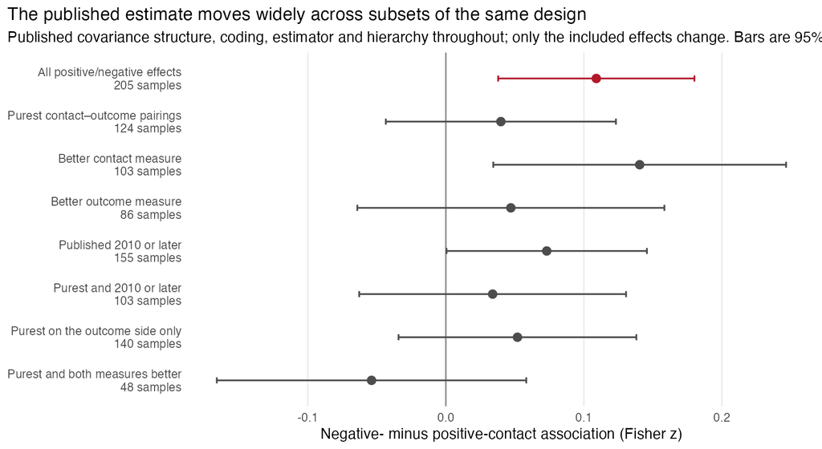

Figure 2: The published contrast refitted inside subsets defined by the workbook’s own quality codes.

Tested this way the quality codes do not deliver a gradient. Pairing purity does not moderate the contrast (0.015, *p* = .564), although the purest subset sits well below the full sample. Reporting quality moderates it only marginally (0.122, *p* = .061). The one code that clearly does moderate favours the published claim: the asymmetry is *larger* where the contact measure is better rated (-0.057, *p* = .032).

The subsets therefore establish that the published contrast is loosely pinned down. Moving between defensible subsets of the same design runs it from -0.054 to 0.140, and most of those estimates cannot be told apart from zero. The evidence for a quality gradient behind that spread is weak, and where a gradient does appear it favours the published estimate.

Adjustment rather than subsetting avoids choosing a boundary at all. Table 5 adds the workbook’s design and context codes (year, sample size, contact- and outcome-measure quality, pairing purity, reporting quality, outcome type, outgroup coding, conflict setting, sample prejudice, country and sample type) as covariates, mean-centred so the contrast is read at the average study. Nothing that is a relabelling of contact valence enters: the workbook’s contact-measure *type* code, for instance, is very nearly valence itself, with 391 of 392 type-6 effects positive and 207 of 217 type-7 effects negative, and conditioning on it would remove the comparison rather than clean it.

Table 5: The valence contrast before and after adjustment for the workbook’s design and context codes, under each covariance structure.

Adjusting for the workbook's design and context codes

| Covariance structure | Model | Estimate | 95% CI | p |
| --- | --- | --- | --- | --- |
| Shared intercept, signed (published) | Unadjusted | 0.109 | [0.017, 0.201] | 0.020 |
| Shared intercept, signed (published) | Adjusted | 0.075 | [-0.020, 0.171] | 0.122 |
| Valence-specific, correlation fixed at zero | Unadjusted | 0.032 | [-0.034, 0.098] | 0.339 |
| Valence-specific, correlation fixed at zero | Adjusted | −0.014 | [-0.078, 0.050] | 0.669 |
| Valence-specific, correlation estimated | Unadjusted | −0.042 | [-0.084, 0.001] | 0.057 |
| Valence-specific, correlation estimated | Adjusted | −0.044 | [-0.082, -0.005] | 0.026 |

These adjusted contrasts standardise the comparison across recorded study characteristics. They are not an identified causal contrast: several of those characteristics, including measure quality and pairing purity, are themselves consequences of which valence a study chose to measure.

## Within samples that measured both valences

The cleanest comparison holds the sample constant. I identified every outcome group in which the same sample contributed both a positive- and a negative-contact effect against the same source-coded outcome label, and took the difference in congruently coded Fisher-transformed effects within each group. My main analysis uses the 191 groups containing exactly one effect of each valence, from 67 samples in 41 papers. Because both effects come from the same participants and carry the same source-coded outcome description, differences in outgroup, setting and sample composition cannot drive the contrast, and differences in outcome operationalisation can do so only to the extent that the workbook’s outcome labels group together instruments that in fact differ. The two contact measures are of course different instruments, so this design does not hold the quality of the contact measure constant; I return to that in the robustness checks.

Pooling the pairs in a three-level model with cluster-robust inference at the paper level gives -0.053 (95% CI [-0.093, -0.013], *t*(32.4) = -2.67, *p* = .012). The negative-contact association is, if anything, slightly weaker within samples: a mean *r* of 0.300 against 0.349 for positive contact, with the negative-contact effect larger in 40% of pairs. Including the 15 further groups that hold several effects of one valence, averaged within valence, gives -0.042 (95% CI [-0.081, -0.002]).

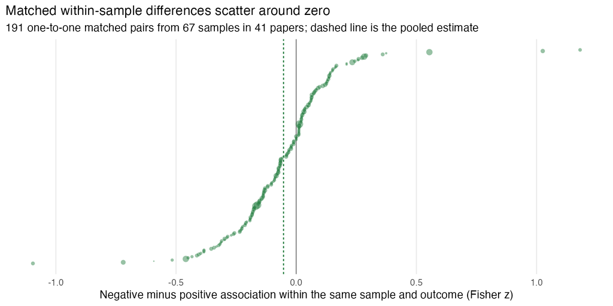

Figure 3: Within-sample differences between the negative- and positive-contact association, one point per matched pair, sized by sample size.

The two correlations in a pair come from the same participants, so their sampling errors are correlated by an amount the workbook does not report. Across assumed correlations from 0 to .90 the estimate moves from -0.053 to -0.058, so it is stable under the working assumptions I can examine, though I cannot rule out that the true covariances vary across pairs in ways this grid does not capture.

## Which samples measured both valences

The matched design buys internal comparability at the cost of restricting the evidence to 78 of 205 samples, and those samples differ from the rest. Against the 119 samples that measured positive contact only, they are more recent (mean year 2016 against 2009, standardised difference 0.72), their contact–outcome pairings are rated purer (1.39 against 2.19 on a scale where 1 is purest, -0.74), and their reporting is rated better (0.51).

This limits generalisation rather than internal validity. Holding the sample and the coded outcome fixed removes confounding between valence and everything that travels with a study, which is what the between-study contrast cannot do. But the samples in which that is possible have unusually strong positive-contact associations, so the resulting estimate describes what a change of valence does inside a study, not what the average published positive- and negative-contact correlations are.

It also cuts the other way for the published contrast. The entire disagreement between the two designs sits on the positive-contact side. The negative-contact association is 0.301 in the samples that measured both valences and 0.307 in the few that measured negative contact alone. The positive-contact association falls from 0.343 in the samples that measured both to 0.257 in those that never measured negative contact, samples whose pairings the workbook rates less pure and whose reporting it rates worse. Whether that gap reflects genuinely weaker positive contact in those settings or attenuation in cruder studies, the published contrast rests on it.

## Robustness

Every alternative inclusion rule I examined gives a negative contrast (Table 6), with point estimates between -0.056 and -0.037. Individually, 4 of the 10 have intervals excluding zero and 6 do not; the latter are the smaller subsets, and these rows are best read as descriptive, since several rest on fewer than twenty papers. Dropping each paper in turn from the main analysis moves the estimate only between -0.060 and -0.047. Only 9 matched pairs predate 2010, too few to fit, so these data say nothing about publication period.

Table 6: Within-sample contrast under alternative inclusion rules. Negative values indicate a weaker negative-contact association.

Robustness of the within-sample contrast

| Specification | Pairs | Samples | Estimate | 95% CI | p |
| --- | --- | --- | --- | --- | --- |
| One-to-one matched pairs (main) | 191 | 67 | −0.053 | [-0.093, -0.013] | 0.012 |
| All matched outcome groups | 206 | 78 | −0.042 | [-0.081, -0.002] | 0.040 |
| Purest effects only | 130 | 57 | −0.050 | [-0.103, 0.003] | 0.064 |
| Direction-congruent effects only | 197 | 74 | −0.053 | [-0.090, -0.015] | 0.007 |
| Both contact measures better rated | 77 | 37 | −0.040 | [-0.096, 0.017] | 0.154 |
| Higher-quality outcome measure | 56 | 39 | −0.044 | [-0.181, 0.092] | 0.505 |
| Outgroup coded prejudiced-against | 165 | 60 | −0.041 | [-0.085, 0.003] | 0.068 |
| Outgroup not coded prejudiced-against | 41 | 19 | −0.056 | [-0.139, 0.027] | 0.169 |
| Published 2010 or later | 197 | 71 | −0.047 | [-0.088, -0.006] | 0.025 |
| One outcome pair per sample | 78 | 78 | −0.037 | [-0.096, 0.022] | 0.215 |

Two challenges to the paired design deserve separate answers. The first is that 191 pairs come from only 67 samples, so most of the apparent replication is within-sample. Cluster-robust variance estimation at the paper level already accounts for that, and collapsing the data before fitting confirms it: one difference per sample gives -0.053 ([-0.095, -0.011], *p* = .015), and the negative-contact effect is the larger one in only 34% of the 67 samples whose difference is not exactly zero (sign test *p* = .014). Collapsing all the way to one difference per paper leaves the estimate at -0.039 with 41 units and an interval that includes zero ([-0.084, 0.007]).

The second is that the two contact measures inside a pair are different instruments, so a poorer negative-contact measure could produce the result on its own. The workbook rates measure quality, and within pairs the two ratings are identical in 181 of 191 cases, with the negative-contact measure rated marginally better on average (2.98 against 3.09, where lower is better). Restricting to pairs whose measures are rated equally gives -0.045 ([-0.083, -0.007], *p* = .023). That rating is coarse and says nothing about item counts, reliability or the skew that comes with negative contact being rarer, so this check bounds one version of the concern rather than disposing of it.

That residue is the most serious objection to the within-sample result, and I cannot answer it from this workbook. Negative contact is less frequent than positive contact in most samples, so its measures are more skewed and more range-restricted, and both attenuate a correlation. A within-sample difference of -0.053 is small enough to be produced by that asymmetry alone even if each negative experience carried more weight than each positive one, and the rarity that produces the attenuation is exactly what the paper’s sequential-sampling account predicts. Settling it requires the means, standard deviations or prevalences of the two contact measures, which the workbook does not record; the primary papers sometimes do, and correcting the paired correlations for the ratio of contact-measure dispersions would bound the artefact. Until that is done, the within-sample estimate constrains the meta-analytic contrast, not the psychological claim.

The workbook’s binary coding of whether the outgroup is one the sample is prejudiced against did not moderate the within-sample contrast (difference 0.017, *p* = .457), so the range-restriction mechanism to which part of the asymmetry is attributed does not show up here. This is a weak test: the code is binary rather than a graded measure of sample prejudice, and the matched subset is small for moderation. Regressing the paired differences on their standard errors gave no sign of small-study effects (*p* = .658), though this too is a weak check, since selective reporting could act on either association separately or on their difference.

## What I take from this

The published contrast of 0.090 is what these data give under one covariance structure, on one coding, with every coded effect included. Each of those conditions is load-bearing, and it is worth being precise about which of my checks are independent of one another.

The specification result is the central one. Estimating the cross-valence correlation rather than fixing it at $-1$ gives -0.042 (95% CI [-0.084, 0.001]), and fixing it at zero gives 0.032, in the published direction but with a *p* value of 0.39, moving to -0.014 once the workbook’s design and context codes are adjusted for. On these data the published structure fits worst of the three by a wide margin.

The correlation-estimated model and the matched-pairs analysis are not independent evidence. With cross-valence correlations of 0.69 between samples and 0.88 between papers, the former is already close to a within-cluster comparison: dropping the 127 single-valence samples entirely moves it only from -0.042 to -0.047. They are one argument made in two ways.

The subset and adjustment analyses use the same effects and the same workbook codes, so they are not independent replications; what they do not require is any change to the covariance structure. The published model, refitted among the effects the workbook itself rates as the purest tests of a contact–outcome link, gives 0.040; adjusted for the workbook’s design and context codes on the full sample it gives 0.075, with an interval including zero. The estimate depends on which effects are included. Tested as interactions rather than subsets, however, the quality codes do not moderate the contrast consistently, and contact-measure quality moderates it in the direction that favours the published claim, so this is a matter of imprecision rather than of an artefact.

So I read this as evidence that the workbook does not establish a general negativity asymmetry in contact–prejudice associations, rather than as evidence that no asymmetry exists. Two limits bound that reading. First, the samples that make the matched comparison possible have unusually strong positive-contact associations, as the previous section sets out; that analysis is internally clean and externally unrepresentative, and its agreement with the full-sample respecification is partly a consequence of the two being close relatives. What neither design offers is a comparison that is both confounding-free and representative of the literature. Second, these are cross-sectional associations between self-reported contact and self-reported prejudice. A negativity bias in how people weight experiences is a within-person, process-level claim, and a difference between two between-person correlations would be indirect evidence about it even if it were reliable.

Settling the question would need designs that measure both valences in the same participants on the same outcome scale, with comparable frequency distributions and ideally longitudinally. Primary studies of that kind may well exist without reporting the information a meta-analysis of this form requires; what I can say is that the 67 samples in this workbook that come closest do not show the asymmetry.

## Reproducibility

All analyses run from the authors’ public workbook, downloaded from their [OSF project](https://osf.io/38rpj/) and not redistributed here. The analysis is in `scripts/analysis.R` and the figures in `scripts/figures.R`. The supplement documents coding decisions, the full specification comparison, and additional checks.

## References

Paolini, Stefania, Meghann Gibbs, Brett Sales, Danielle Anderson, and Kylie McIntyre. 2024. “Negativity Bias in Intergroup Contact: Meta-Analytical Evidence That Bad Is Stronger Than Good, Especially When People Have the Opportunity and Motivation to Opt Out of Contact.” *Psychological Bulletin* 150 (8): 921–64. https://doi.org/10.1037/bul0000439.

Pustejovsky, James E., and Elizabeth Tipton. 2022. “Meta-Analysis with Robust Variance Estimation: Expanding the Range of Working Models.” *Prevention Science* 23 (3): 425–38. https://doi.org/10.1007/s11121-021-01246-3.

## Footnotes

[^1]: A defender of the published structure could argue that a shared intercept on the signed scale captures nuisances that move both *signed* correlations in the same direction, such as a response style that inflates positive correlations generally. That is a coherent estimand, and I do not suggest the authors intended the $-1$ as a substantive claim. The difficulty is that the quantity being tested is explicitly a difference in directionally predicted strength, and for that quantity the constraint is the wrong one. Among the structures compared, AIC clearly favours the one that estimates the correlation. The shared-intercept model sits on the boundary of the valence-specific family, at a correlation of $\pm 1$ with equal variances, where AIC’s penalty is an approximation; the gaps here are large enough that this does not affect the ordering.